# Logistic Regression For Binary Classification For Bank Personal-Loan Modelling

Matthew Curcio

# 1 Executive Summary

The management of Thera Bank wanted to explore ways of converting its customers to personal loan customers. A previous advertising campaign was run last year to elicit loans from customers. From the 5000 customers selected for the campaign a conversion rate of over 9% success was found. One Logistic Regression (Model #2) was found to have high accuracy (96.10%) and high specificity (98.67%). and sensitivity (71.88%).

The optimum customer for Personal loans was found to be;

[output not shown]

# 2 Introduction

## 2.1 Understanding Logistic Regression

Logistic Regression is often used as a binary classifier where the dependent variable is a categorical outcome, for example; go/no-go, loan/reject-loan. Using Logistic Regression, we may also calculate the presence or absence of a product or quality when the *decision boundary* is not clear.

Logistic regression may also be familiar as the *exponential growth curve* (Eq. #1) given a limited set of resources. It may be used for other biological situations such as dose-response curves, enzyme kinetic curves, median lethal dose curve (LD-50), and survival.

$$\begin{equation}
f(x) ~=~ \frac{M}{1 + Ae^{-r(x - x_0)}}
\end{equation}$$

where $M$ is the curve’s maximum value, $r$ is the maximum growth rate, $x_0$ is the midpoint of the curve, and $A$ is the number of doublings to reach $M$.[^1]

In the specific case of *Logistic Regression for Binary Classification* (Eq. #2), $M$, $A$ and $r$ take on the value 1 and a probability between 0 and 1 is generated.

$$\begin{equation}
f(x) ~=~ \frac{1}{1 + e^{-(WX+b)}}
\end{equation}$$

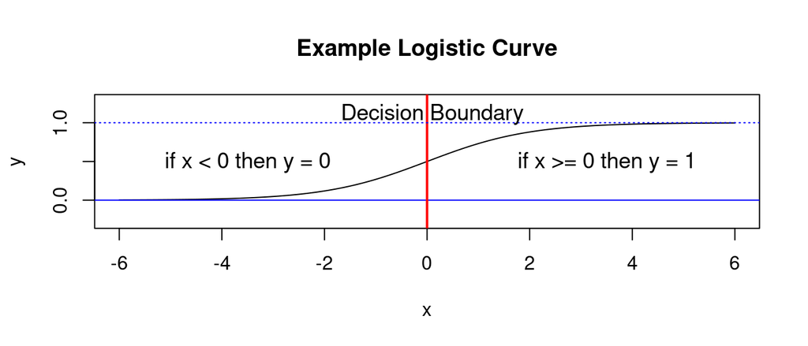

Figure 2.1: Example Logistic Curve

Because the logistic equation is exponential, it is easier to work with the formula in terms of its *log-odds*. Where odds are the probabilities of success over failure. By using log-odds, logistic regression may be more easily expressed as a set of linear equations in terms of x. Therefore Logistic Regression is considered a *generalized linear model* (GLM).

$$\begin{equation}
ln \left( \frac {p}{1-p} \right) =~ \sum_i^{k} \beta_i x_i
\end{equation}$$

Eliminate the natural log by taking the exponent on both sides;

$$\begin{equation}
\frac {p}{1-p} =~ exp \left ( \sum_i^{k} \beta_i x_i \right )
\end{equation}$$

To evaluate the 2 models the Akaike Information Criterion [^2] will be used. With AIC smaller values indicate better fitting models.

$$\begin{equation}
AIC ~=~ 2 K ~-~ 2ln (\widehat{L})
\end{equation}$$

Where $ln (\widehat{L})$ is the log-likelihood estimate, $K$ is the number of parameters.

## 2.2 Thera Bank Loan Campaign

The management of Thera Bank wants to explore various ways of converting its liability customers to personal loan customers yet to also retain them as depositors. A previous advertising campaign was run last year to elicit loans from customers. From the 5000 customers selected for the campaign a conversion rate of over 9% success was found. The purpose of this work is to understand if it is possible to convert a higher percentage of bank users to loan recipients.

A large portion of the feature variables relate to whether bank customers have accounts with Thera Bank. Will a study of these features provide information on which ones to focus on for future loan campaign advertising?

At the present time, the feature `Zip code` will not be used. It is possible to correlate home zip code and neighborhood qualities but this is for a future project.

```
Bank_Personal_Loan_Modeling data file can be found at:
https://www.kaggle.com/krantiswalke/bank-personal-loan-modelling
```

### 2.2.1 13 Feature Attributes Were Collected

| Abbreviation | Attribute |
| --- | --- |
| ID | Customer ID |
| Age | Age |
| Experience | Yrs experience |
| ZIP Code | Zip code |
| Family | Family size |
| Income | Annual income, $k |
| Mortgage | Home mortgage, $k |
| CCAvg | Mean credit card spending, $k |
| Education | Education Level (1,2,3) |
| Securities Account | Customer has securities (0,1) |
| CD Account | Customer has CDs (0,1) |
| Online | Customer uses internet banking (0,1) |
| Credit card | Customer uses credit card (0,1) |

### 2.2.2 Target - Personal Loan Conversion

| Abbreviation | Target |
| --- | --- |
| Personal Loan | Customer accepted loan? (0,1) |

# 3 Model # 1 - Using 12 features and 1 Target variable

## 3.1 R Libraries

```r
# Load Libraries
Libraries <- c("doMC", "knitr", "readr", "tidyverse", "caret", "e1071")
for (p in Libraries) {
  library(p, character.only = TRUE)
}
```

## Import Data

```r
model_1 <- read_csv("Bank_Personal_Loan_Modelling.csv",
                    col_types = cols(ID = col_skip(),
                                     `ZIP Code` = col_skip(),
                                     `CD Account` = col_factor(levels = c("0", "1")),
                                     CreditCard = col_factor(levels = c("0", "1")),
                                     Education = col_factor(levels = c("1", "2", "3")),
                                     Family = col_integer(),
                                     Online = col_factor(levels = c("0", "1")),
                                     `Personal Loan` = col_factor(levels = c("0", "1")),
                                     `Securities Account` = col_factor(levels = c("0", "1"))))
# View(model_1)
dim(model_1)
```

```
## [1] 5000   12
```

## 3.2 Model 1 Generation

```r
set.seed(1000)
index <- createDataPartition(model_1$`Personal Loan`, p = 0.8, list = FALSE)
training_set_1 <- model_1[index,]

# The `test_set_1` and `Class_test` data sets are not produced since the Logit
# run with 11 features was is not the final model.

# The first training run is to determine if all 11 features are necessary for
# our final logistic regression model.

set.seed(1000)
registerDoMC(cores = 3)      # Start multi-processor mode
start_time <- Sys.time()     # Start timer

# Create model, 10X fold CV repeated 5X
tcontrol <- trainControl(method = "repeatedcv",
                         number = 10,
                         repeats = 5)

model_result_1 <- train(`Personal Loan` ~ .,
                        data = training_set_1,
                        trControl = tcontrol,
                        method = "glm",        # glm = 'Generalized Linear Model'
                        family = "binomial")

end_time <- Sys.time()      # End timer
end_time - start_time       # Display time
```

```
## Time difference of 1.194248 secs
```

```r
registerDoSEQ()             # Stop multi-processor mode
```

## 3.3 Summary - Model 1

```r
summary(model_result_1)
```

```
##
## Call:
## NULL
##
## Deviance Residuals:
##     Min       1Q   Median       3Q      Max
## -2.3243  -0.1860  -0.0694  -0.0219   4.1907
##
## Coefficients:
##                               Estimate Std. Error z value Pr(>|z|)
## (Intercept)                 -1.126e+01  2.085e+00  -5.399 6.70e-08 ***
## Age                         -7.493e-02  7.828e-02  -0.957  0.33850
## Experience                   7.905e-02  7.763e-02   1.018  0.30859
## Income                       6.085e-02  3.349e-03  18.170  < 2e-16 ***
## Family                       6.486e-01  8.731e-02   7.429 1.10e-13 ***
## CCAvg                        1.615e-01  4.916e-02   3.286  0.00102 **
## Education2                   3.812e+00  2.991e-01  12.747  < 2e-16 ***
## Education3                   3.932e+00  2.964e-01  13.265  < 2e-16 ***
## Mortgage                     1.417e-04  6.616e-04   0.214  0.83041
## `\\`Securities Account\\`1` -9.014e-01  3.384e-01  -2.663  0.00774 **
## `\\`CD Account\\`1`          3.839e+00  3.866e-01   9.929  < 2e-16 ***
## Online1                     -7.283e-01  1.862e-01  -3.911 9.21e-05 ***
## CreditCard1                 -1.013e+00  2.406e-01  -4.213 2.52e-05 ***
## ---
## Signif. codes:  0 '***' 0.001 '**' 0.01 '*' 0.05 '.' 0.1 ' ' 1
##
## (Dispersion parameter for binomial family taken to be 1)
##
##     Null deviance: 2529.63  on 3999  degrees of freedom
## Residual deviance:  928.51  on 3987  degrees of freedom
## AIC: 954.51
##
## Number of Fisher Scoring iterations: 8
```

## 3.4 Observations - Model 1

- Model contains 12 features and 1 dependent variable.
- Age, Experience and Mortgage have P-values greater than 5%.

| Feature | P-value |
| --- | --- |
| Age | 0.33850 |
| Experience | 0.30859 |
| Mortgage | 0.83041 |

- The Akaike information criterion (AIC)[^3] for model #1 is 954.51.

## 3.5 Decision - Model 1

- Model should DROP: **Age, Experience, Mortgage, Zip code**

# 4 Model # 2 - Uses 9 features and 1 Target variable

The second model uses 9 features:

1. Income
2. Family
3. Average Credit Card Debt
4. CD Account
5. Education-2
6. Education-3
7. Online banking
8. Securities Account
9. Has Credit Card

### Import Bank Loan Data

```r
model_2  <- read_csv("Bank_Personal_Loan_Modelling.csv",
                     col_types = cols(Age = col_skip(),
                                      ID = col_skip(),
                                      Mortgage = col_skip(),
                                      Experience = col_skip(),
                                      `ZIP Code` = col_skip(),
                                      `CD Account` = col_factor(levels = c("0", "1")),
                                      CreditCard = col_factor(levels = c("0", "1")),
                                      Education = col_factor(levels = c("1", "2", "3")),
                                      Family = col_integer(),
                                      Online = col_factor(levels = c("0", "1")),
                                      `Personal Loan` = col_factor(levels = c("0", "1")),
                                      `Securities Account` = col_factor(levels = c("0", "1"))))
dim(model_2)
```

```
## [1] 5000    9
```

## 4.1 Model 2 Generation

```r
# Partition data into training and testing sets
set.seed(1000)
index <- createDataPartition(model_2$`Personal Loan`, p = 0.8, list = FALSE)

training_set_2 <- model_2[ index, ]
test_set_2     <- model_2[-index, ]

Class_test_2 <- as.factor(test_set_2$`Personal Loan`)

set.seed(1000)
registerDoMC(cores = 3)           # Start multi-core
start_time <- Sys.time()          # Start timer

# Create model, 10X fold CV repeated 5X
tControl <- trainControl(method = "repeatedcv",
                           number = 10,
                           repeats = 5,
                           savePredictions = "final") # IMPORTANT: Saves predictions

model_result_2 <- train(`Personal Loan` ~ .,
                     data = training_set_2,
                     trControl = tControl,
                     method = "glm",
                     family = "binomial")

end_time <- Sys.time()           # End timer
end_time - start_time            # Display time
```

```
## Time difference of 0.9687424 secs
```

```r
registerDoSEQ()                  # Stop multi-core
```

## 4.2 Summary - Model 2

```r
summary(model_result_2)
```

```
##
## Call:
## NULL
##
## Deviance Residuals:
##     Min       1Q   Median       3Q      Max
## -2.3571  -0.1893  -0.0691  -0.0219   4.1676
##
## Coefficients:
##                               Estimate Std. Error z value Pr(>|z|)
## (Intercept)                 -13.042368   0.635359 -20.528  < 2e-16 ***
## Income                        0.061022   0.003311  18.430  < 2e-16 ***
## Family                        0.646500   0.087081   7.424 1.14e-13 ***
## CCAvg                         0.157995   0.048693   3.245  0.00118 **
## Education2                    3.795839   0.298495  12.717  < 2e-16 ***
## Education3                    3.881894   0.291956  13.296  < 2e-16 ***
## `\\`Securities Account\\`1`  -0.888602   0.337540  -2.633  0.00847 **
## `\\`CD Account\\`1`           3.847597   0.385513   9.980  < 2e-16 ***
## Online1                      -0.728666   0.186064  -3.916 9.00e-05 ***
## CreditCard1                  -1.003529   0.239914  -4.183 2.88e-05 ***
## ---
## Signif. codes:  0 '***' 0.001 '**' 0.01 '*' 0.05 '.' 0.1 ' ' 1
##
## (Dispersion parameter for binomial family taken to be 1)
##
##     Null deviance: 2529.63  on 3999  degrees of freedom
## Residual deviance:  929.95  on 3990  degrees of freedom
## AIC: 949.95
##
## Number of Fisher Scoring iterations: 8
```

## 4.3 Confusion Matrix - Model 2

```r
Predicted_test_vals <- predict(model_result_2, test_set_2[, -5])

confusionMatrix(Predicted_test_vals, Class_test_2, positive = "1")
```

```
## Confusion Matrix and Statistics
##
##           Reference
## Prediction   0   1
##          0 892  27
##          1  12  69
##
##                Accuracy : 0.961
##                  95% CI : (0.9471, 0.9721)
##     No Information Rate : 0.904
##     P-Value [Acc > NIR] : 5.695e-12
##
##                   Kappa : 0.7584
##
##  Mcnemar's Test P-Value : 0.02497
##
##             Sensitivity : 0.7188
##             Specificity : 0.9867
##          Pos Pred Value : 0.8519
##          Neg Pred Value : 0.9706
##              Prevalence : 0.0960
##          Detection Rate : 0.0690
##    Detection Prevalence : 0.0810
##       Balanced Accuracy : 0.8527
##
##        'Positive' Class : 1
##
```

## 4.4 Observations - Model 2

- All Model 2 features have (**P-values <= 0.01**).
- Model 1 & 2: Akaike information criterion

| Model # | Features | AIC |
| --- | --- | --- |
| 1 | 12 | 954.51 |
| 2 | 9 | 949.95 |

- Model #2 has a **lower AIC** and will be used.
- Model #2 Beta-Parameters ranked in order of importance:

| Feature | Beta-Parameters |
| --- | --- |
| Education-3 | 3.881894 |
| CD Account-1 | 3.847597 |
| Education-2 | 3.795839 |
| Family | 0.646500 |
| CCAvg | 0.157995 |
| Income | 0.061022 |
| Online-1 | -0.728666 |
| Securities Account-1 | -0.888602 |
| CreditCard-1 | -1.003529 |

- The 3 most *Positive Beta-Parameters* are;
  1. Education-3,
  2. Ownership of Certificates of Deposit,
  3. Education-2.
- The 3 most *Negative Beta-Parameters* are;
  1. Ownership of Credit Card,
  2. Ownership of Securities,
  3. Use of Online banking.
- Model 2 Statistics

| Model Statistics | Value |
| --- | --- |
| Accuracy | 0.9610 |
| Sensitivity | 0.7188 |
| Specificity | 0.9867 |

# 5 Conclusion

- A good customer profile would be:
  1. One **with higher education**,
  2. who **owns CD’s**,
  3. who does **Not have a Securities Act.**,
  4. A customer who does **Not have a Credit Card**.
  5. AND, of course, a person with an **income >= $55 k**.
[^1]: https://en.wikipedia.org/wiki/Malthusian_growth_model
[^2]: https://en.wikipedia.org/wiki/Akaike_information_criterion
[^3]: https://en.wikipedia.org/wiki/Akaike_information_criterion